# Diagnosticar, priorizar y evaluar la bioseguridad con R

Clínica, Salud Pública y Bioseguridad · Práctica guiada

## Propósito y escenario

Al concluir, podrá **calcular un diagnóstico docente de salud pública, localizar brechas ponderadas y comparar cuatro medidas de bioseguridad conservando el emparejamiento por cuidador**. Elaborará una recomendación apoyada en tablas, figuras y límites de interpretación.

Usted integra un equipo veterinario que debe revisar cinco centros ficticios y proponer una mejora para el manejo de terrarios de anfibios o reptiles. Primero realiza un diagnóstico general; después identifica las brechas; finalmente examina una simulación de transferencia entre recintos.

**Todos los datos son simulados.** Los nombres Z1–Z5 y C01–C10 no identifican instituciones ni personas. Esta es una actividad de análisis en computadora: no requiere animales, cultivos, patógenos ni manipulación de trazadores.

Tiempo propuesto: 180 minutos, individual o en parejas. Conserve el orden de las tres etapas. Consulte `docs/metodologia_y_fuentes.md` para distinguir los elementos publicados de las adaptaciones docentes.

## Preparación: tres herramientas de R

Abra el proyecto `.Rproj`. El panel **Files** debe mostrar las carpetas `R` y `datos`. La ruta de trabajo será la raíz del proyecto; no necesita `setwd()`.

```r
# source() lee y ejecuta un archivo de codigo.
source("R/funciones.R")
dir.create("resultados", showWarnings = FALSE)

# <- guarda un resultado con un nombre; $ selecciona una columna.
ejemplo <- data.frame(centro = c("Z1", "Z2"), puntos = c(57, 72))
ejemplo$puntos
```

```
## [1] 57 72
```

```r
# [filas, columnas] selecciona una parte de una tabla.
ejemplo[ejemplo$puntos >= 60, ]
```

```
##   centro puntos
## 2     Z2     72
```

**Antes de avanzar:** identifique dónde aparecen la tabla y el vector de puntos. `NA` significa información ausente; no equivale al número cero.

## 1. Agudelo: diagnóstico de salud pública

### Del artículo a la práctica

Agudelo-Suárez y Villamil-Jiménez (2009) organizaron cuatro instrumentos según la fuente de información. Consideraron salud animal, salud ambiental, seguridad, conservación y educación. En esta versión abreviada se proponen 20 indicadores docentes con respuesta de 0 a 4, cada uno con máximo de 20 puntos. El total máximo es 400. **Estos ítems y sus pesos no son una reproducción del instrumento validado.**

Se utiliza la clasificación publicada solo para mostrar el algoritmo: 0–99 deficiente; 100–349 regular; 350–400 bueno. Una categoría global puede ocultar una dimensión débil; por ello también se revisa el perfil.

### Leer y comprender los datos

```r
datos_a <- leer_csv("agudelo_respuestas.csv")
head(datos_a)
```

```
##   item centro  visita respuesta procedencia
## 1  A01     Z1 Inicial         0    SIMULADO
## 2  A02     Z1 Inicial         0    SIMULADO
## 3  A03     Z1 Inicial         1    SIMULADO
## 4  A04     Z1 Inicial         2    SIMULADO
## 5  A05     Z1 Inicial         1    SIMULADO
## 6  A06     Z1 Inicial         2    SIMULADO
```

```r
table(datos_a$visita)
```

```
##
##     Inicial Seguimiento
##         100         100
```

```r
sum(is.na(datos_a$respuesta))  # Contar respuestas desconocidas.
```

```
## [1] 1
```

Una fila es un indicador de un centro en una visita. Hay cinco centros y dos visitas. En este caso simulado, el seguimiento incorpora un mayor cumplimiento programado; no permite atribuir el cambio a una intervención real.

### Calcular el total y representar el cambio

Abra `R/01_agudelo.R` y localice la conversión `puntos <- respuesta / 4 * maximo`. Por ejemplo, respuesta 3 obtiene 15 de 20. El script suma únicamente cuando están disponibles los 20 indicadores.

```r
source("R/01_agudelo.R")
```

```
##    centro      visita respondidos esperados puntaje_400  categoria
## 1      Z1     Inicial          20        20         145    Regular
## 2      Z2     Inicial          20        20         190    Regular
## 3      Z3     Inicial          20        20         235    Regular
## 4      Z4     Inicial          20        20         340    Regular
## 5      Z5     Inicial          19        20          NA Incompleto
## 6      Z1 Seguimiento          20        20         185    Regular
## 7      Z2 Seguimiento          20        20         220    Regular
## 8      Z3 Seguimiento          20        20         305    Regular
## 9      Z4 Seguimiento          20        20         375      Bueno
## 10     Z5 Seguimiento          20        20         390      Bueno
```

```r
# Total por centro y visita, con indicador de integridad.
agudelo_totales
```

```
##    centro      visita respondidos esperados puntaje_400  categoria
## 1      Z1     Inicial          20        20         145    Regular
## 2      Z2     Inicial          20        20         190    Regular
## 3      Z3     Inicial          20        20         235    Regular
## 4      Z4     Inicial          20        20         340    Regular
## 5      Z5     Inicial          19        20          NA Incompleto
## 6      Z1 Seguimiento          20        20         185    Regular
## 7      Z2 Seguimiento          20        20         220    Regular
## 8      Z3 Seguimiento          20        20         305    Regular
## 9      Z4 Seguimiento          20        20         375      Bueno
## 10     Z5 Seguimiento          20        20         390      Bueno
```

```r
cambio
```

```
##   centro puntaje_400_inicial puntaje_400_seguimiento cambio_puntos
## 1     Z1                 145                     185            40
## 2     Z2                 190                     220            30
## 3     Z3                 235                     305            70
## 4     Z4                 340                     375            35
## 5     Z5                  NA                     390            NA
```

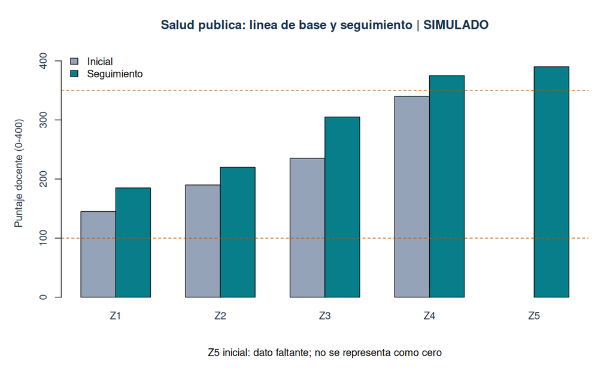

**Interpretación guiada:** una mejora de puntos puede ocurrir sin cambio de categoría porque la banda regular es amplia. Un total incompleto no permite comparar el cambio. No complete datos desconocidos con cero ni aumente el resultado proporcionalmente para forzarlo a 400.

### Ejercicio 1

1. Identifique el centro con mayor cambio calculable e indique cuántos puntos ganó.
2. Explique por qué no se calcula el cambio de Z5. ¿Qué evidencia solicitaría?
3. Consulte `01_agudelo_perfiles.csv`. Para Z1 en la visita inicial, identifique su dimensión con menor porcentaje y explique por qué el total no basta.
4. Proponga una pregunta para cada una de las cuatro fuentes de información y señale qué evidencia permitiría corroborar la respuesta.

## 2. Dulzaines: brechas de bioseguridad

### Conservar las ponderaciones

Dulzaines Castañeda et al. (2010) proponen seis acápites con máximos de 9, 20, 16, 29, 18 y 8 puntos. Sumarlos produce un máximo de 100. Un punto de esta escala no representa la misma dimensión que un punto del índice docente anterior: **no se deben promediar ambos puntajes**.

La práctica utiliza subtotales ficticios. No reconstruye el anexo por ítems.

```r
leer_csv("catalogo_dulzaines.csv")
```

```
##   seccion                                              nombre maximo
## 1      D1                      Ubicacion, vinculos y traslado      9
## 2      D2                     Control sanitario y saneamiento     20
## 3      D3     Alimentacion, conservacion y suministro de agua     16
## 4      D4            Diagnostico y vigilancia epizootiologica     29
## 5      D5                     Salud y estado de la exhibicion     18
## 6      D6 Inmunoprofilaxis, medicina preventiva y terapeutica      8
```

```r
source("R/02_dulzaines.R")
```

```
##   centro obtenido                     categoria
## 1     Z1       57 Fuera del intervalo publicado
## 2     Z2       72                  Desprotegido
## 3     Z3       83        Medianamente protegido
## 4     Z4       92                     Protegido
## 5     Z5       47 Fuera del intervalo publicado
##    seccion maximo obtenido brecha_puntos brecha_pct
## 16      D4     29       18            11   37.93103
## 6       D2     20       10            10   50.00000
## 11      D3     16        8             8   50.00000
## 21      D5     18       12             6   33.33333
## 1       D1      9        4             5   55.55556
## 26      D6      8        5             3   37.50000
```

```r
dulzaines_totales
```

```
##   centro obtenido                     categoria
## 1     Z1       57 Fuera del intervalo publicado
## 2     Z2       72                  Desprotegido
## 3     Z3       83        Medianamente protegido
## 4     Z4       92                     Protegido
## 5     Z5       47 Fuera del intervalo publicado
```

Observe el tratamiento de valores menores de 60: el artículo no les asigna una categoría. El programa informa la laguna. No es válido inventar un umbral y atribuirlo a los autores.

### Diferenciar dos preguntas de priorización

La **brecha en puntos** muestra cuánto falta respecto del máximo ponderado. La **brecha porcentual** muestra la fracción que falta dentro de cada acápite. Sus órdenes pueden diferir.

```r
# Cambie Z1 por otro centro y vuelva a ejecutar estas lineas.
centro_a_revisar <- "Z1"
revision <- d[d$centro == centro_a_revisar, ]
revision[order(revision$brecha_puntos, decreasing = TRUE),
         c("seccion", "maximo", "obtenido", "brecha_puntos", "brecha_pct")]
```

```
##    seccion maximo obtenido brecha_puntos brecha_pct
## 16      D4     29       18            11   37.93103
## 6       D2     20       10            10   50.00000
## 11      D3     16        8             8   50.00000
## 21      D5     18       12             6   33.33333
## 1       D1      9        4             5   55.55556
## 26      D6      8        5             3   37.50000
```

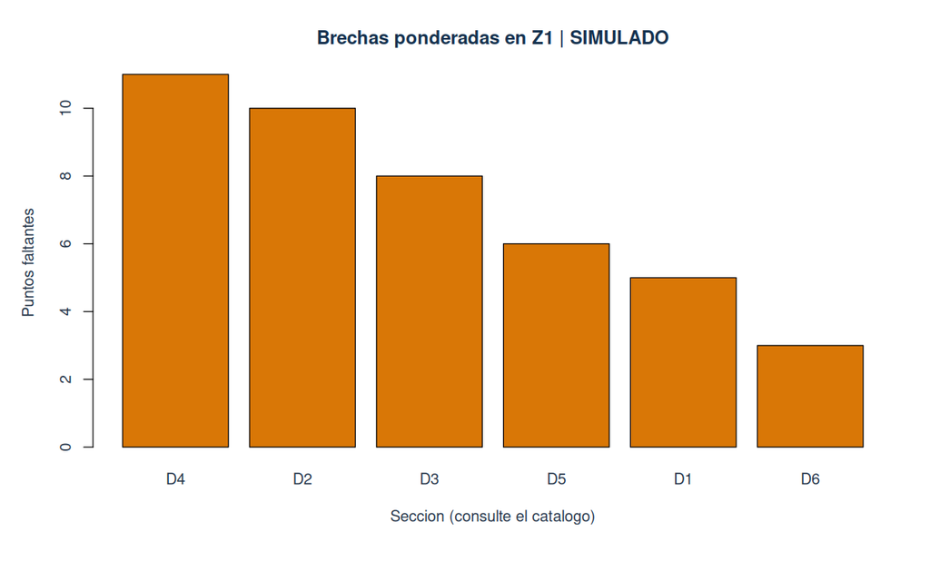

La figura generada por el script corresponde a Z1. Para graficar otro centro, modifique `centro_elegido` dentro de `R/02_dulzaines.R` y vuelva a ejecutarlo.

### Ejercicio 2

1. Indique el total y la clasificación de Z2 y Z4.
2. Para Z1, compare el acápite con mayor brecha en puntos con el de mayor brecha porcentual. Explique la diferencia en una frase.
3. Seleccione dos brechas para atender primero. Justifique por ruta de exposición y consecuencias, además de su puntaje.
4. Explique qué concluiría sobre un centro con 59 puntos y qué información falta en la clasificación publicada.

## 3. Jensen: ¿funciona la medida en la simulación?

### Introducción al diseño experimental

Jensen, Jensen y Bertelsen (2021) evaluaron transferencia de trazador UV. Diez cuidadores realizaron los cuatro escenarios en orden aleatorizado:

| Escenario | Guantes entre terrarios | Esponja |
| --- | --- | --- |
| Control | Sin cambio | Compartida |
| Guantes | Cambio en cada terrario | Compartida |
| Utensilios | Sin cambio | Dedicada a cada terrario |
| Combinados | Cambio en cada terrario | Dedicada a cada terrario |

Cada ensayo incluye diez terrarios. Los dos primeros son controles previos; el tercero es la fuente; los siete siguientes son los receptores. Cada terrario tiene cuatro superficies, calificadas de 0 a 3. Por ello, el total principal es:

$$7 terrarios × 4 superficies × 3 puntos = 84.$$

El máximo de 84 pertenece a **cada ensayo cuidador × escenario**, no al estudio completo. Los datos individuales de los artículos no se utilizaron en la simulación.

```r
datos_j <- leer_csv("jensen_uv.csv")
head(datos_j)
```

```
##   cuidador  escenario orden_ensayo terrario superficie puntaje_uv procedencia
## 1      C01 Utensilios            1        1      Pared          0    SIMULADO
## 2      C01 Utensilios            1        1    Refugio          0    SIMULADO
## 3      C01 Utensilios            1        1   Sustrato          0    SIMULADO
## 4      C01 Utensilios            1        1   Bebedero          0    SIMULADO
## 5      C01 Utensilios            1        2      Pared          0    SIMULADO
## 6      C01 Utensilios            1        2    Refugio          0    SIMULADO
```

```r
nrow(datos_j)  # 1600 registros de superficies.
```

```
## [1] 1600
```

```r
leer_csv("jensen_orden_ensayos.csv")[1:8, ]
```

```
##   cuidador  escenario orden_ensayo
## 1      C01 Utensilios            1
## 2      C01    Guantes            2
## 3      C01 Combinados            3
## 4      C01    Control            4
## 5      C02 Combinados            1
## 6      C02    Control            2
## 7      C02    Guantes            3
## 8      C02 Utensilios            4
```

El orden de los escenarios cambia entre cuidadores; el recorrido de terrarios se mantiene fijo. El simulador no incorpora un efecto de aprendizaje por orden: en un experimento real habría que examinarlo y prevenir arrastre entre ensayos.

### Agrupar antes de comparar

```r
source("R/03_jensen.R")
```

```
##    escenario n_cuidadores media mediana desviacion minimo maximo
## 1    Control           10  24.2    25.0   4.661902     14     29
## 2    Guantes           10  18.2    18.5   5.940445      9     27
## 3 Utensilios           10  25.5    26.0   4.790036     17     31
## 4 Combinados           10   2.8     2.5   2.097618      1      8
##
##  Friedman rank sum test
##
## data:  total_uv and escenario and cuidador
## Friedman chi-squared = 23.121, df = 3, p-value = 3.81e-05
##
##    escenario n_pares diferencia_media diferencia_mediana reduccion_medias_pct
## 1    Guantes      10             -6.0               -7.5            24.793388
## 2 Utensilios      10              1.3                3.0            -5.371901
## 3 Combinados      10            -21.4              -21.5            88.429752
##   p_sin_ajuste     p_holm
## 1  0.074085291 0.14817058
## 2  0.437627444 0.43762744
## 3  0.005825024 0.01747507
```

```r
resumen_jensen
```

```
##    escenario n_cuidadores media mediana desviacion minimo maximo
## 1    Control           10  24.2    25.0   4.661902     14     29
## 2    Guantes           10  18.2    18.5   5.940445      9     27
## 3 Utensilios           10  25.5    26.0   4.790036     17     31
## 4 Combinados           10   2.8     2.5   2.097618      1      8
```

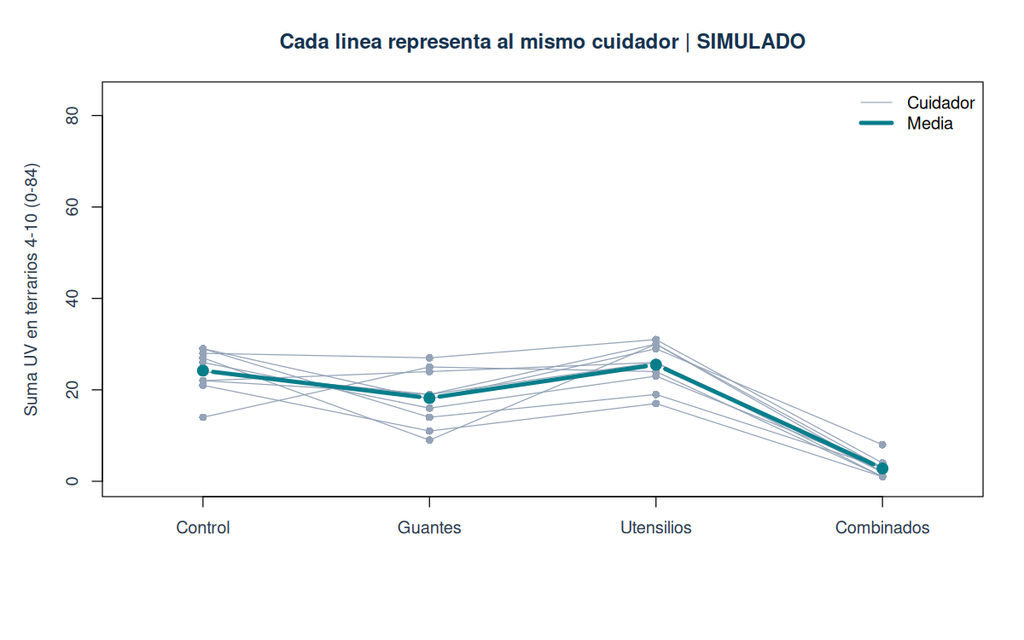

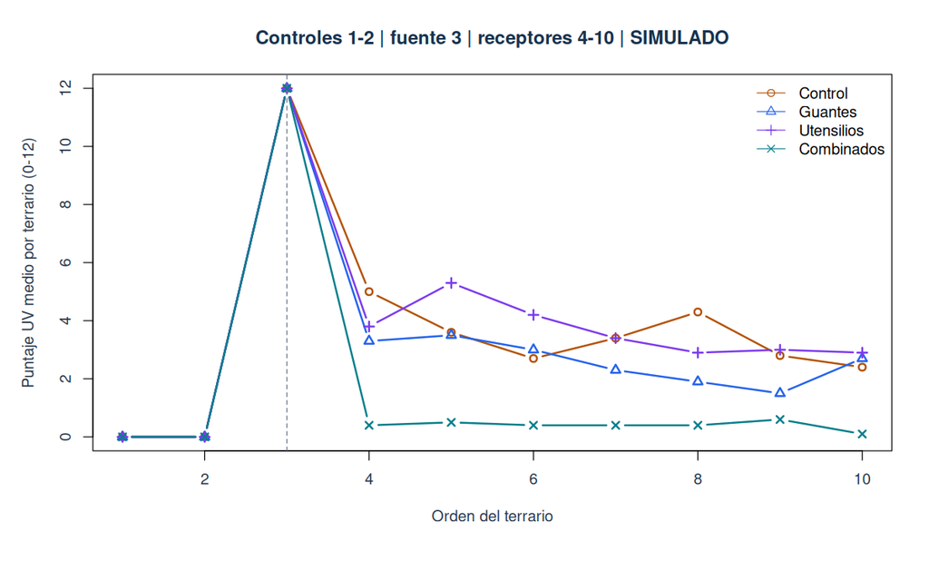

Cada línea gris corresponde a un cuidador. La línea de medias ayuda a resumir, pero no sustituye la variación individual. Revise si todos muestran el mismo patrón.

### Comparación pareada y tamaño del cambio

Usaremos Friedman para comparar los cuatro escenarios dentro de cada cuidador. Después, tres comparaciones Wilcoxon pareadas contra control con ajuste de Holm. El artículo reportó ANOVA y Tukey; esta adaptación hace explícitas las mediciones repetidas. No intenta reproducir sus valores p.

```r
prueba_friedman
```

```
##
##  Friedman rank sum test
##
## data:  total_uv and escenario and cuidador
## Friedman chi-squared = 23.121, df = 3, p-value = 3.81e-05
```

```r
comparaciones[, c("escenario", "diferencia_media", "reduccion_medias_pct", "p_holm")]
```

```
##    escenario diferencia_media reduccion_medias_pct     p_holm
## 1    Guantes             -6.0            24.793388 0.14817058
## 2 Utensilios              1.3            -5.371901 0.43762744
## 3 Combinados            -21.4            88.429752 0.01747507
```

Una diferencia intervención menos control negativa significa menor puntaje UV. La reducción relativa compara medias; **no es eficacia contra una infección**. El valor p no mide la magnitud del cambio ni la probabilidad de que la hipótesis nula sea verdadera. Con diez cuidadores, empates y una prueba aproximada, interprete siempre junto con la figura y las diferencias.

### Ejercicio 3

1. Explique por qué 1,600 superficies no equivalen a 1,600 cuidadores independientes.
2. Identifique el escenario con menor media UV y cuantifique la diferencia y reducción relativa frente al control.
3. Compare la conclusión usando diferencias y usando `p_holm`. Si no detecta diferencia en una comparación, ¿demuestra que las medidas son equivalentes?
4. Explique por qué deben excluirse la fuente y los controles previos del total principal de 84.
5. Mencione dos limitaciones del trazador para inferir transmisión de enfermedad.

## 4. Integrar: de los resultados al plan de mejora

Complete `plantillas/entrega.qmd` con una conclusión por módulo y una matriz de tres acciones. La matriz es un recurso docente adicional; no se atribuye a ninguna de las metodologías originales.

| Hallazgo y evidencia | Ruta de exposición o consecuencia | Medida propuesta | Responsable y plazo propuesto | Cómo verificar |
| --- | --- | --- | --- | --- |
| Completar | Completar | Completar | Completar | Indicador, meta y método |

Incluya una acción de diagnóstico/documentación, una de bioseguridad estructural u operativa y una prueba de la intervención de manejo de terrarios. Los responsables y plazos son propuestas para el caso ficticio.

**Producto:** informe de 4–6 páginas o equivalente en HTML, tres conclusiones, al menos tres figuras (una por módulo), respuestas de los ejercicios y matriz de mejora. Si el HTML excede esa longitud, priorice respuestas breves; el código queda en el proyecto y no necesita copiarlo íntegramente al informe.

**Criterios propuestos:** cálculo e integridad 25%; interpretación y límites 25%; diseño experimental y comparación 25%; plan verificable 20%; claridad y reproducibilidad 5%. Estos criterios suman 100% de esta práctica; no modifican las ponderaciones oficiales de la asignatura.

## Lecturas

- Agudelo-Suárez y Villamil-Jiménez (2009), métodos y tablas 1–2.
- Dulzaines Castañeda et al. (2010), máximos, clasificación y anexo 1.
- Jensen et al. (2021), diseño experimental y escala UV.
- Agudelo-Suarez (2017), reflexión de cierre: ¿qué responsabilidades de salud pública exceden el control de enfermedades transmisibles?

Referencias completas y decisiones de adaptación: `docs/metodologia_y_fuentes.md`.